# Lab2

Hunter DeVoe

2023-01-27

# Tasks

## Task 1

- Obtain the working directory by issuing the command getwd():

```r
getwd()
```

```
## [1] "C:/Users/Hunter/Desktop/Math 4753 Labs/Lab 2"
```

## Task 2

- Read in the data and print the first six lines

```r
epagas <- read.csv("EPAGAS-1.csv", header = TRUE)
head(epagas, 6)
```

```
##    MPG
## 1 36.3
## 2 41.0
## 3 36.9
## 4 37.1
## 5 44.9
## 6 36.8
```

## Task 3

- Make the object mpg, the number of miles per gallon vector.

```r
mpg <- epagas[['MPG']]
head(mpg, 6)
```

```
## [1] 36.3 41.0 36.9 37.1 44.9 36.8
```

- Transform the mpg variable to z and verify these results.

```r
# Now convert to the Z-scale and print contents
z = ((mpg - mean(mpg)) / sd(mpg))
z
```

```
##   [1] -0.287026279  1.656811633 -0.038876758  0.043839749  3.269783517
##   [6] -0.080235012 -2.892596246  0.085198002  2.111752421 -0.121593265
##  [11] -1.775923403  0.126556256  1.739528140 -0.162951519 -1.693206896
##  [16] -0.204309772 -1.569132136  0.167914509  0.209272762 -1.403699122
##  [21]  1.450020366 -0.204309772  0.250631016 -1.279624361  1.325945605
##  [26] -0.245668025  0.291989269  0.291989269  1.243229098 -1.155549601
##  [31] -0.328384532  0.374705776 -0.411101039  0.374705776 -0.452459293
##  [36]  0.498780537  0.540138790 -0.535175800 -0.576534053 -0.783325320
##  [41]  0.622855297  0.829646564 -0.617892306 -0.907400081  0.664213550
##  [46]  0.995079578 -0.700608813 -1.072833094  0.746930057  1.119154338
##  [51] -0.287026279 -0.080235012 -1.858639910 -0.245668025  1.450020366
##  [56] -0.162951519 -0.369742786  0.498780537  0.581497043  0.953721324
##  [61]  1.656811633 -2.148147684  0.126556256 -1.610490389  0.002481495
##  [66]  0.250631016  0.002481495  0.705571804  0.829646564 -0.493817546
##  [71]  0.002481495  0.085198002  1.532736873  0.167914509  0.043839749
##  [76]  0.333347523 -0.452459293 -0.576534053 -0.121593265 -1.031474841
##  [81]  0.043839749  1.367303859 -0.121593265  0.002481495 -1.279624361
##  [86]  1.284587352  0.416064030 -0.741967067 -0.907400081  1.036437831
##  [91]  1.201870845 -0.038876758 -1.693206896 -1.320982615  1.160512592
##  [96] -1.238266108 -0.080235012 -0.824683574  0.457422283 -0.038876758
```

1. Mean

```r
round(mean(z), digits = 4)
```

```
## [1] 0
```

2. Standard Deviation

```r
(sd(z))^2
```

```
## [1] 1
```

- Using z, find the values of mpg that are possible outliers.

```r
mpg[abs(z) >= 2 & abs(z) <= 3]
```

```
## [1] 30.0 42.1 31.8
```

- Using z, find the values of mpg that are defined as outliers. Note that by The Empirical Rule, almost all observations in a data set will have a z-score less than 3 in absolute value. Therefore, we can use this to find any possible outliers in the mpg data set.

```r
mpg[(abs(z) > 3)]
```

```
## [1] 44.9
```

- Using the lattice package, construct a dotplot with colors, Red = outlier, Blue = possible outlier.

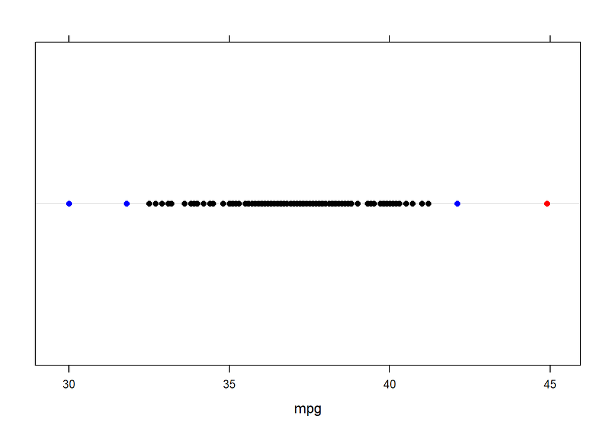

```r
# Plot the outliers in red and the possible outliers in blue
mycol = ifelse(abs(z)>3, "Red",
        ifelse(abs(z)>=2 &abs(z)<=3,"Blue", "Black"))

#Plot points with different plotting shapes
mypch = ifelse(abs(z)>3, 20,
        ifelse(abs(z)>=2 &abs(z)<=3,21, 22))

dotplot(mpg,col=mycol)
```

## Task 4

- Make a boxplot of the mpg variable.
  - Make the box black.
  - Put a notch where the median goes
  - Put a title on the graph.
  - Make the plot horizontal.

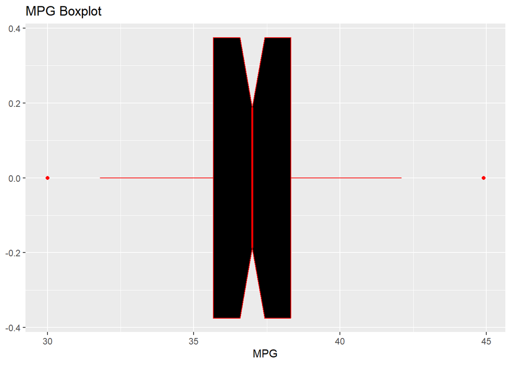

```r
ggplot(data = epagas, aes(x = MPG)) + geom_boxplot(color = "red", fill = "black", notch = TRUE) + ggtitle("MPG Boxplot")
```

- Using Chebyshev’s theorem predict the proportion of data within 2 standard deviations of the mean of the mpg data.

Chebyshev’s theorem states that at least $1 - \frac{1}{k^2}$ of the data lies within k standard deviations of the mean. When k = 2, we get $1 - \frac{1}{2^2}$, which simplifies to $\frac{3}{4}$. Therefore, about 3/4 of the data, or 75%, should be within 2 standard deviations of the mean.

- Use R to calculate the exact proportion within 2 standard deviations of the mean.

```r
length(mpg[abs(z)<2])/length(mpg)
```

```
## [1] 0.96
```

- Does Chebyshev agree with the data?

I think Chebyshev would agree. His theorem states that at **least** 3/4, or 75%, of the data is within 2 standard deviations of the mean. We can see that 96% of the data lies within 2 standard deviations of the mean, proving Chebyshev’s Rule.

- Now use the Empirical rule, what proportion (according to the rule) of the data should be within 2 standard deviations of the mean?  
  According to the Empirical rule, 95% of the data should be within 2 standard deviations of the mean.
- How well does it correspond?

I think it corresponds well. We found that 96% of the MPG data is within 2 standard deviations of the mean, which is extremely close to what the empirical rule states.

- Is the Empirical rule valid in this case? Why?

One of the best ways to see if the Empirical rule is valid is to create a histogram of the data. The Empirical rule holds only if the data set forms a bell or mound shape, so we can analyze the histogram and see what shape it takes on.

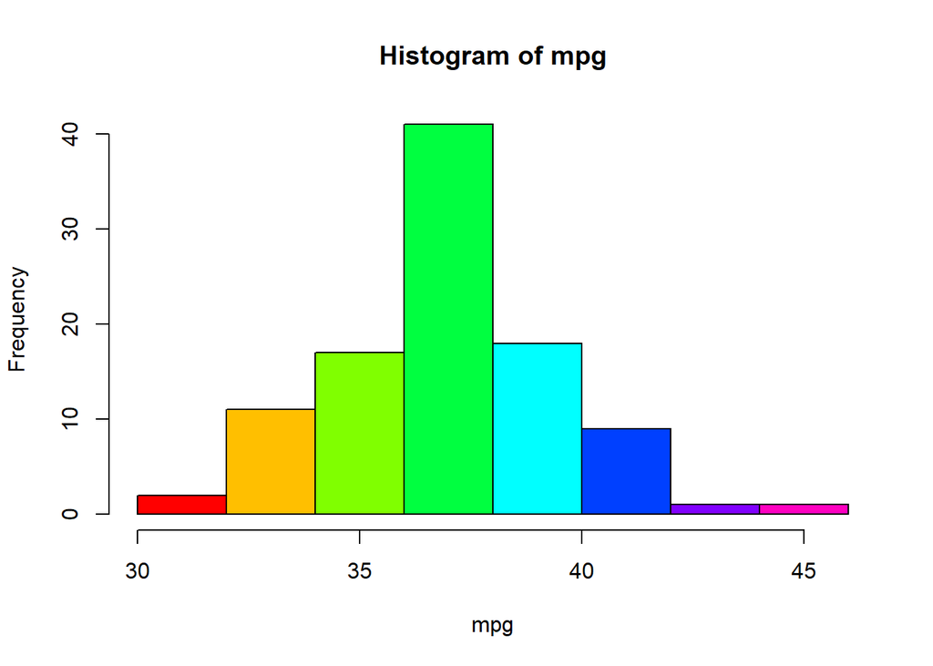

```r
hist(mpg, col = rainbow(8))
```

We can see that our histogram does have a similar shape to a bell curve. Therefore, it is safe to assume that the Empirical rule is valid for our data. Why? The Empirical rule states that if a data set is has a mound shaped, symmetric distribution, then about 68% of the data is 1 standard deviation away from the mean, 95% is 2 standard deviations away from the mean, and almost all measurements are 3 standard deviations away from the mean. Since the histogram resembles a bell or a mound, we can safely assume that the Empirical rule holds.